# Applying the basics of efficient R programming

For this exercise, you will need to download the file: temp_stations.csv

Load the content of this file into a variable in your R environment with the following command:

```r
t <- read.csv("data/temp_stations.csv") # You may need to adjust the path to the file, depending on how you have organized your folders.
```

```r
head(t)
```

```
##     datetime starkville   columbus   meridian     biloxi
## 1 2022-01-01       18.1 15.3903241 19.1763887 19.8906805
## 2 2022-01-02       -0.9  0.7630577 -0.3803543  0.8910247
## 3 2022-01-03       -1.9 -7.3876835 -0.8971593  1.0825752
## 4 2022-01-04         NA  0.3948917 -0.1458191  5.6266367
## 5 2022-01-05        1.1 -1.7254413 -1.8997366  8.0543028
## 6 2022-01-06       -1.6 -4.0392856 -0.9410461 -0.2371790
```

Before we start the actual exercise, let’s have a quick look at the data. Your first task is to plot the temperatures for the Starkville station as a function of the date. Your plot should like this:

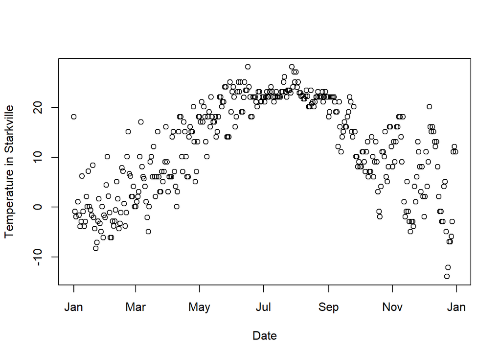

## Part 1 - No more for loops…

For the following exercise, you will not write a single for loop! The list of functions which you will need for part 1 of this exercise is (do not use any other functions!):

```r
colnames (optional)
apply
min
which.min
names (optional)
table
month
by
t.test
```

### 1.1 Add a column with the minimum temperature recorded each day.

Your dataframe should now look like this:

| date | starkville | columbus | meridian | biloxi | mintemp |
| --- | --- | --- | --- | --- | --- |
| 2022-01-01 | 18.1 | 15.3903241 | 19.1763887 | 19.8906805 | 15.3903241 |
| 2022-01-02 | -0.9 | 0.7630577 | -0.3803543 | 0.8910247 | -0.9000000 |
| 2022-01-03 | -1.9 | -7.3876835 | -0.8971593 | 1.0825752 | -7.3876835 |
| 2022-01-04 | NA | 0.3948917 | -0.1458191 | 5.6266367 | -0.1458191 |
| 2022-01-05 | 1.1 | -1.7254413 | -1.8997366 | 8.0543028 | -1.8997366 |
| 2022-01-06 | -1.6 | -4.0392856 | -0.9410461 | -0.2371790 | -4.0392856 |

### 1.2 Find how many times each station was the coldest of the four.

To do so, we will start by adding a column indicating which station was the coldest. We’ll start by recording the indice (starkville = 1, columbus = 2, meridian = 3, …) and we can match the indice to the name later.

| date | starkville | columbus | meridian | biloxi | mintemp | coldestStation |
| --- | --- | --- | --- | --- | --- | --- |
| 2022-01-01 | 18.1 | 15.3903241 | 19.1763887 | 19.8906805 | 15.3903241 | 2 |
| 2022-01-02 | -0.9 | 0.7630577 | -0.3803543 | 0.8910247 | -0.9000000 | 1 |
| 2022-01-03 | -1.9 | -7.3876835 | -0.8971593 | 1.0825752 | -7.3876835 | 2 |
| 2022-01-04 | NA | 0.3948917 | -0.1458191 | 5.6266367 | -0.1458191 | 3 |
| 2022-01-05 | 1.1 | -1.7254413 | -1.8997366 | 8.0543028 | -1.8997366 | 3 |
| 2022-01-06 | -1.6 | -4.0392856 | -0.9410461 | -0.2371790 | -4.0392856 | 2 |

You can now use the function **table** to find how many times each indice appears in the colum **coldestStation**. Store the result in a variable named **cold**

```
##
##   1   2   3   4
##  82 143 137   3
```

Use the function **names** to make your variable **cold** look nicer:

```
## starkville   columbus   meridian     biloxi
##         82        143        137          3
```

### 1.3 Summary per month

Add a column containing the month of each observation and then use the function **by** to obtain the minimum temperature recorded in Starkville for each month.

```
## t$month: April
## [1] 0.1
## ------------------------------------------------------------
## t$month: August
## [1] 20.1
## ------------------------------------------------------------
## t$month: December
## [1] -13.9
## ------------------------------------------------------------
## t$month: February
## [1] -6.1
## ------------------------------------------------------------
## t$month: January
## [1] -8.3
## ------------------------------------------------------------
## t$month: July
## [1] 21.1
## ------------------------------------------------------------
## t$month: June
## [1] 16.1
## ------------------------------------------------------------
## t$month: March
## [1] -4.9
## ------------------------------------------------------------
## t$month: May
## [1] 10.1
## ------------------------------------------------------------
## t$month: November
## [1] -4.9
## ------------------------------------------------------------
## t$month: October
## [1] -1.9
## ------------------------------------------------------------
## t$month: September
## [1] 8.1
```

## Part 2 - Statistics

According to this data, were the 2022 temperatures statistically significantly different between Starkville and Columbus? (at the 5% confidence level)  
How about between Starkville and Biloxi?

## Part 3 - Tibbles, tidyr and dplyr

We will use the functionalities of **tibbles** and a few R packages to quickly generate a beautiful plot of the temperatures as a function of the date for each station.

### 3.1 - From dataframes to tibbles

Convert the dataframe **t** into a tibble **tb**:

```r
library("tibble")
library("dplyr")
library("tidyr")
library("ggplot2")

# Let's restart from a fresh version of the t dataframe:
t <- read.csv("data/temp_stations.csv")

tb <- tibble(t)
tb
```

```
## # A tibble: 365 × 5
##    datetime   starkville columbus meridian biloxi
##    <chr>           <dbl>    <dbl>    <dbl>  <dbl>
##  1 2022-01-01       18.1   15.4     19.2   19.9
##  2 2022-01-02       -0.9    0.763   -0.380  0.891
##  3 2022-01-03       -1.9   -7.39    -0.897  1.08
##  4 2022-01-04       NA      0.395   -0.146  5.63
##  5 2022-01-05        1.1   -1.73    -1.90   8.05
##  6 2022-01-06       -1.6   -4.04    -0.941 -0.237
##  7 2022-01-07       -3.9   -4.84    -4.30   1.73
##  8 2022-01-08       -2.9   -2.87    -2.16  -0.184
##  9 2022-01-09        6.2    2.84     3.11   9.73
## 10 2022-01-10       -0.9    2.45    -1.92   3.30
## # … with 355 more rows
```

Compare what you see (when you type **tb**) with what happens when you display a dataframe (by typing **t** in the R console)

### 3.2 Preparing the data for ggplot

```
## # A tibble: 1,460 × 3
##    datetime   station    temperature
##    <chr>      <chr>            <dbl>
##  1 2022-01-01 starkville      18.1
##  2 2022-01-01 columbus        15.4
##  3 2022-01-01 meridian        19.2
##  4 2022-01-01 biloxi          19.9
##  5 2022-01-02 starkville      -0.9
##  6 2022-01-02 columbus         0.763
##  7 2022-01-02 meridian        -0.380
##  8 2022-01-02 biloxi           0.891
##  9 2022-01-03 starkville      -1.9
## 10 2022-01-03 columbus        -7.39
## # … with 1,450 more rows
```

### 3.3 Plotting the data

Use the function **mutate** to generate a column **date** which contains a date object.  
You now have everything ready to generate a plot like this:

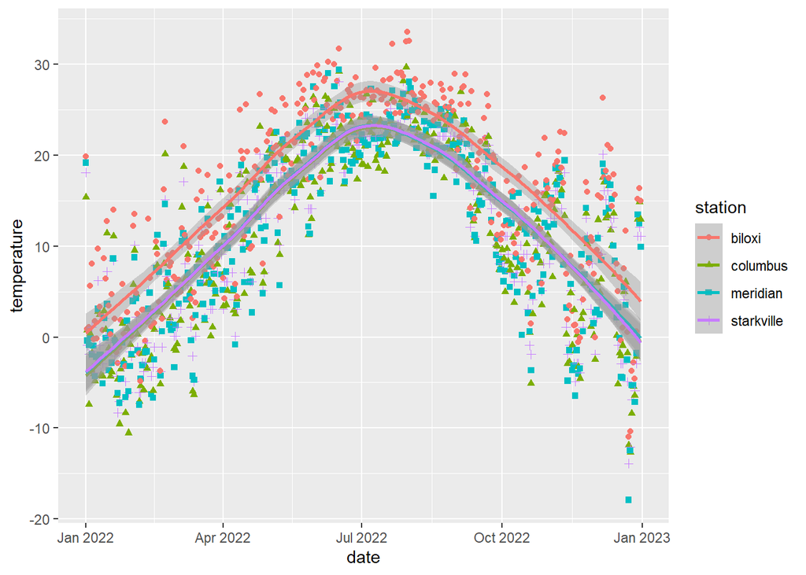